# Tipos de filme de Chris Evans

# Descrição dos dados

Os dados utilizados foram obtidos através do site rotten tomatoes. Mais especificamente, utilizou-se de uma base que contém informações sobre as participações de um certo ator em filmes. Neste relatório, o ator escolhido foi Chris Evans e o objetivo é aplicar algoritmos de agrupamento com a finalidade de identificar e caracterizar os grupos que compõem os filmes desse ator.

Com isso, é possível o acesso as seguintes variáveis para cada um dos 22 filmes disponíveis de Chris Evans: avaliação no rotten tomatoes, nome do filme, papel, bilheteria e ano.

Dado que o objetivo é agrupar os filmes e que a quantidade de variáveis que descrevem cada filme está limitada ao que foi descrito acima, espera-se, a priori, que a avaliação e a bilheteria possam servir para um agrupamento satisfatório. Para confirmar esta hipótese, pode-se observar o gráfico de dispersão dos pontos nas dimensões de avaliação x bilheteria.

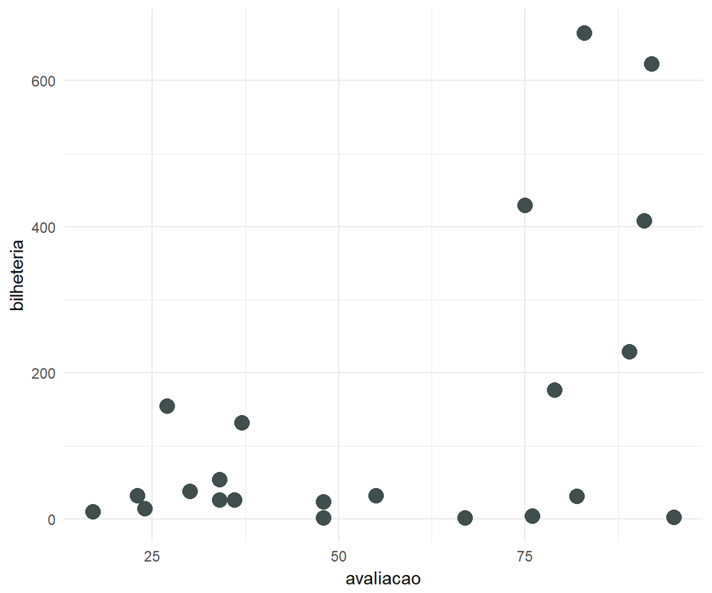

A partir dessa visualização, pode-se perceber uma leve estrutura de grupos. em outras palavras, alguns pontos parecem estar associados de forma que seus comportamentos na avaliação e bilheteria são muito semelhates.

Logo, para que seja possível extrair essa característica de grupos da melhor maneira, deve-se observar as distribuições das variáveis que são de interesse para esse agrupamento em duas dimensões.

Abaixo, pode-se observar como comportam-se essas variáveis.

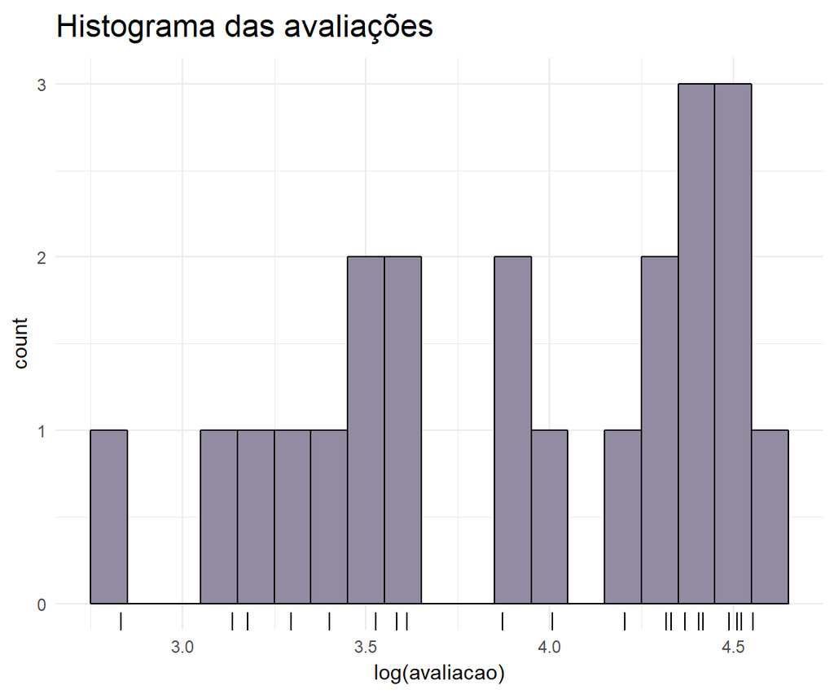

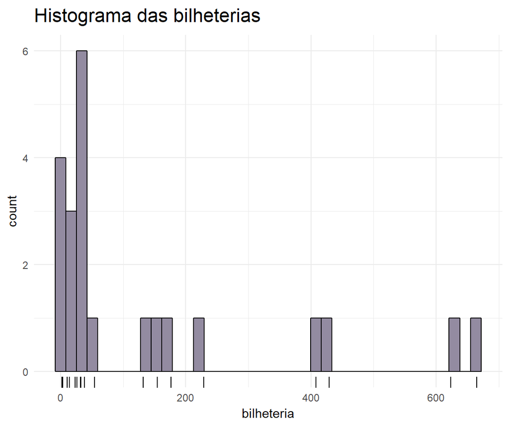

## O que fazer com a distribuição assimétrica da bilheteria?

É perceptível que a distribuição da variável bilheteria não possui um formato simétrico, ou seja, seus valores ocorrem muito mais quando estão próximos de zero e valores mais altos são menos frequentes.

Desse modo, pode-se aplicar uma função logarítimica com o objetivo de reduzir essa distância entre os valores, deixando, assim, a distribuição mais simétrica ( ou próxima de uma distribuição normal).

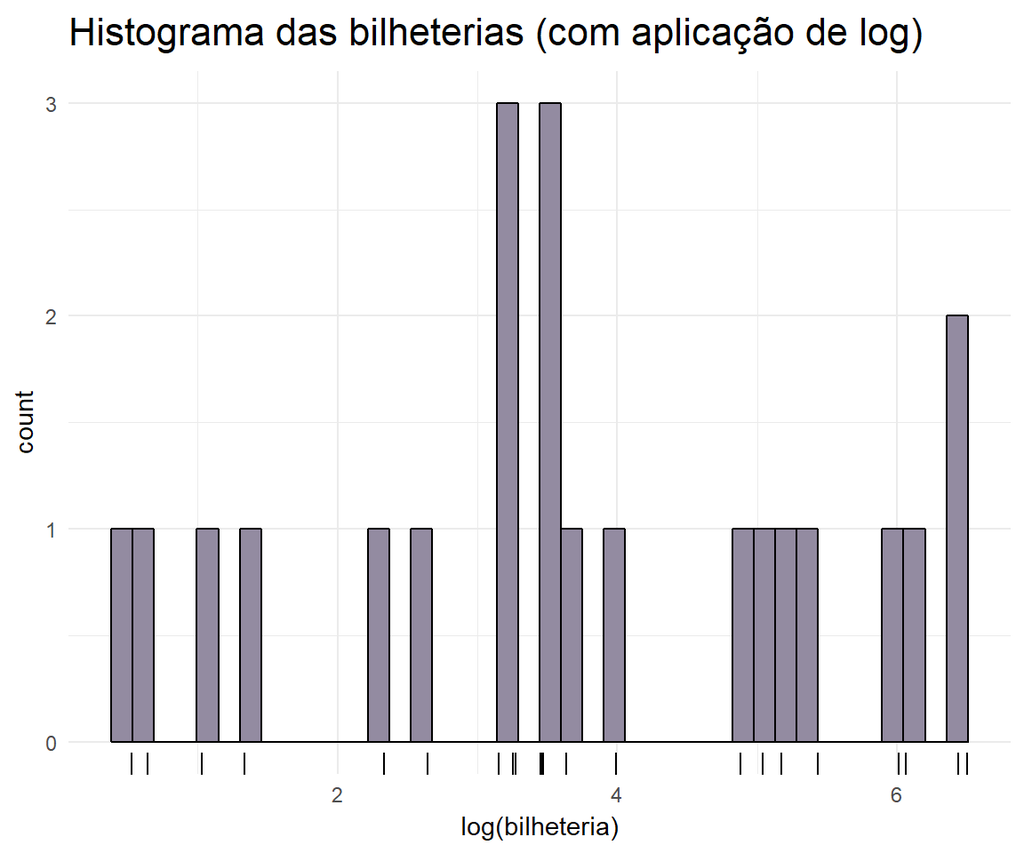

# Agrupamento hierárquico

Nesse momento, inicia-se a etapa de agrupamento propriamente dita. O que acontecerá é que um algoritmo de agrupamento hierárquico será aplicado aos filmes. Nesse algoritmo, os pontos serão colocados em um mesmo grupo de acordo com as suas distâncias para o centro de um dado grupo. Esse processo começa com cada ponto sendo considerado um grupo. No final, todos os pontos estarão no mesmo grupo. A partir do Dendrograma abaixo, a intuição do algoritmo poderá ser melhor entendida.

Além disso, é de extrema importância ressaltar que, como a distância calculada é a euclidiana, as escalas nas quais o pontos estão influenciam no peso de cada termo usado no cálculo.

Por fim, deve-se escolher qual passo do algoritmo tinha o melhor estado de grupos formados antes de juntar todos os pontos em um mesmo grupo. Para isso, o gráfico de linha é útil. A medida de dissimilaridade representa o quão diferente foram os grupos que uniram-se em um dado passo do algoritmo. Desse modo, quando esta medida estiver aumentando muito, pode ser um bom indício de que grupos muito dissimilares estão sendo considerados como um só. Logo, é melhor parar o algoritmo no passo anterior a isso.

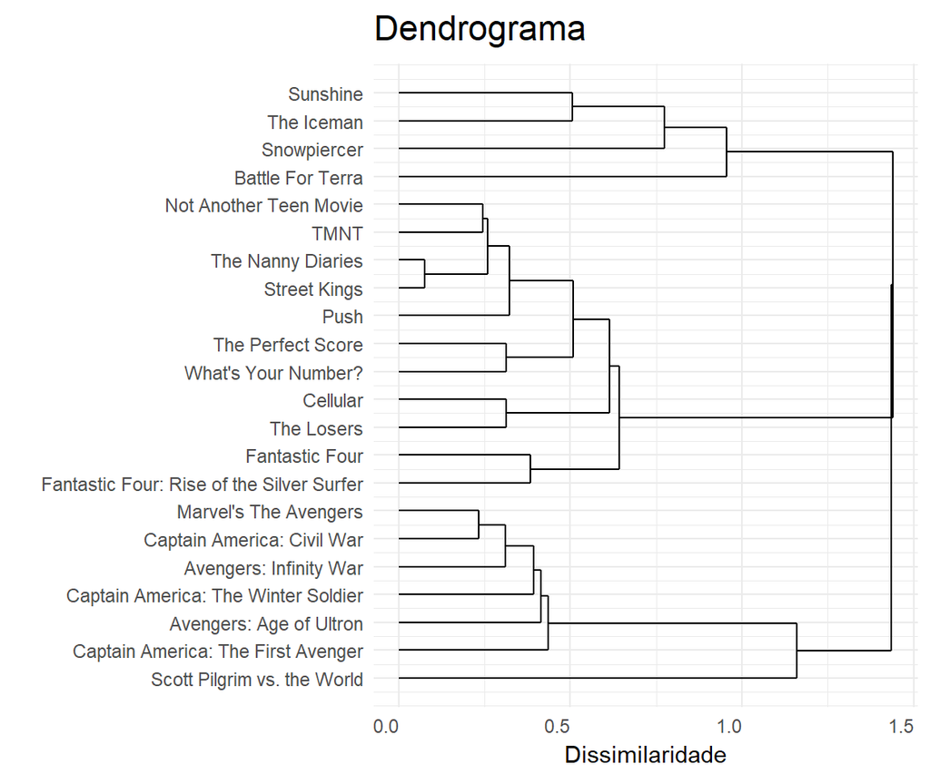

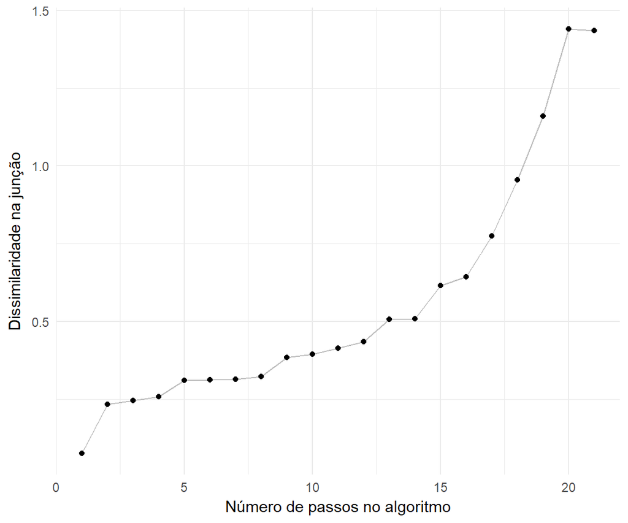

Ao analisar o gráfico de linha logo acima, percebe-se que a dissimilaridade aumenta exponencialmente a partir do passo 16. Isso quer dizer que, aproximadamente, no ponto médio entre 0.50 e 0.75 de dissimilaridade deve-se parar o algoritmo. Ao utilizar o dendrograma, chega-se a conclusão de que 7 grupos pode ser uma boa quantidade, dada a medida de dissimilaridade.

Pode-se, também, ver o gráfico de dispersão na medida em que o algoritmo faz a junção dos grupos.

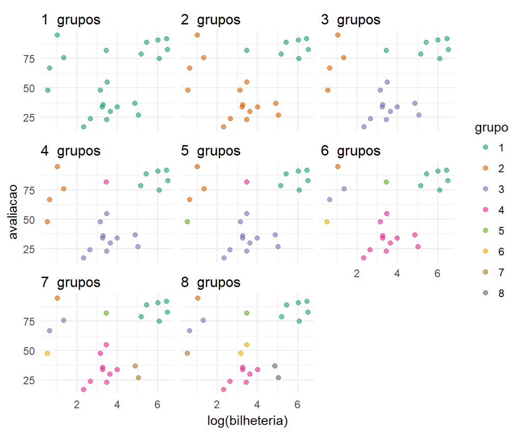

# Dando nome aos bois

- Os sucessos da Marvel:

O grupo 1 é contém todos os filmes nos quais Chris Evans participou de filmes da Marvel como o Capitão América e sob a direção da Disney. Os filmes desse grupo são claramente os maiores sucessos do ator, tanto em bilheteria, quanto na avaliação do RT. Como: Marvel’s the Avengers.

- Pobre e feliz:

O grupo 2 é formado por um filme apenas, devido ao seu comportamento diferenciado. Snowpiercer foi aclamado pelos avaliadores no RT, sendo o filme de maior avaliação entre os disponíveis nos dados, porém não fez tanto sucesso de bilheteria.

- Dinheiro não compra felicidade, mas compra coxinha:

O grupo 3 é formado por filmes que não foram tão felizes quanto o grupo 2 nas suas avaliações, porém ainda estão em uma posição mais alta que a maioria. Todavia, esse grupo também é um desastre em bilheteria.

- Fora Temer:

O grupo 4 é formado por filmes que não foram bem na avaliação, porém ainda possuem dinheiro o bastante pra se unirem. Esse grupo contém a menor nota na avaliação do RT para esse ator, o filme The Perfect Score.

- O diferentão:

O grupo 5 também possui apenas um filme, que bem se encaixaria no grupo 4. Esse filme também não é um dos maiores sucesso de bilheteria, porém está em uma posição diferentona (com relação ao grupo 4) na sua avaliação do rotten tomatoes, que foi relativamente alta.

- Sem um tostão no bolso:

O grupo 6 é o que tem o menor valor de bilheteria. Embora sua avaliação não seja das piores.

- Riquinho, mas sem graça:

O grupo 7 é um caso interessante. Apesar dos valores de bilheteria ser tão alto quanto alguns dos sucessos da Marvel, a avaliação é desastrosa. Coincidentemente (ou não), esses também são filmes do universo Marvel e um é a sequência do outro. Eles são: O Quarteto Fantástico e a sua continuação com o Surfista Prateado.